# Cleaning and Visualizing a Large Genetic Dataset

This code accompanies two datasets on the effects of 10,000 SNPs (single-nucleotide polymorphisms) on two traits, A and B. Each dataset includes an ID number indicating the location of the SNP on the chromosome, the two alleles (A, T, C, or G) that occur in that position, the frequency with which the alleles occur, an estimate of the effect size of the SNP on trait A or B, and the z-score produced when the null hypothesis (that the given SNP has no effect on the given trait) was tested.

The goal is to clean the data and then render a QQ plot of the empirical CDF of p-values vs. the theoretical CDF that would result if the null hypothesis were true for all SNPs.

# Part 1: Cleaning

Move the datasets into the working directory, then define

```r
A = read.delim("A.txt")
B = read.delim("B.txt")
```

For this dataset, all SNPs are intended to be on chromosome 22. Let’s check that’s actually the case.

```r
chromosomes = function(dataset) {
  count = 0
  for (i in dataset[,2]) {if (i != 22) {count = count + 1}}
  print(count)}
chromosomes(A)
```

```
[1] 0
```

```r
chromosomes(B)
```

```
[1] 0
```

The count indicates that no SNPs are off chromosome 22, so no deletions are necessary for this step.

Next we’ll check that each SNP has a unique identifier - if not, we won’t know which SNP the corresponding data belongs to.

```r
SNPs = function(dataset) {
  count = 0
  for (row in 1:nrow(dataset)) {if (is.na(dataset[row, 1])) {count = count + 1}}
  print(count)}
SNPs(A)
```

```
[1] 0
```

```r
SNPs(B)
```

```
[1] 0
```

Both counts are zero, so again no action is necessary.

There are missing values in some of the other columns (e.g. z-scores) which we will need to produce the plot later. Since the data is useless without these values, we’ll delete any rows with missing values in columns 4 through 9.

```r
clean = function(dataset, indicator){
  delete = c()
  for (row in 1:nrow(dataset)) {
    missedVals = is.na(dataset[row, 4:9])
    count = 0
    for (i in missedVals) {if (i == TRUE) {count = count + 1}}
    if (count > 0) {delete = c(delete, row)}}
  dataset = dataset[-c(delete), ]

  #The indicator should be set to TRUE for A and FALSE for B
  #These lines write the previous changes globally so they'll be available at the next step
  if(indicator == TRUE){assign('A', dataset,envir=.GlobalEnv)}
  if(indicator == FALSE){assign('B', dataset,envir=.GlobalEnv)}}
clean(A, TRUE)
clean(B, FALSE)
```

Next we’ll check for problems with the listed alleles. Let’s see what values A1 (allele 1) and A2 are assigned:

```r
levels(A[,4])
```

```
[1] "A" "C" "G" "T"
```

```r
levels(A[,5])
```

```
 [1] "A"  "AA" "AC" "AG" "AT" "C"  "CA" "CC" "CG" "CT" "D"  "G"  "GA" "GC" "GG" "GT" "T"  "TA" "TC" "TG"
[21] "TT"
```

```r
levels(B[,4])
```

```
[1] "A" "C" "G" "T"
```

```r
levels(B[,5])
```

```
 [1] "A"  "AC" "AG" "AT" "C"  "CA" "CC" "CG" "CT" "D"  "G"  "GA" "GC" "GG" "GT" "T"  "TA" "TC" "TG" "TT"
```

We see that A1 is always listed with an acceptable value (A, T, C, or G), but A2 is not. Presumably double entries like AA are typos which we should correct; all other nonstandard entries are deleted by the following code:

```r
doubles = function(dataset, indicator){
  #Replace duplicates with singletons
  delete = c()
  for (row in 1:nrow(dataset)) {
    if (dataset[row, 5] == "AA") {dataset[row, 5] = "A"}
    if (dataset[row, 5] == "TT") {dataset[row, 5] = "T"}
    if (dataset[row, 5] == "CC") {dataset[row, 5] = "C"}
    if (dataset[row, 5] == "GG") {dataset[row, 5] = "G"}

  #If A1 or A2 are listed as anything other than A,T,C,G, delete the row
    if (!(dataset[row, 4] %in% c("A", "T", "C", "G"))) {delete = c(delete, row)}
    if (!(dataset[row, 5] %in% c("A", "T", "C", "G"))) {delete = c(delete, row)}}
  dataset = dataset[-c(delete), ]

  #Write changes globally
  if(indicator == TRUE){assign('A', dataset, envir=.GlobalEnv)}
  if(indicator == FALSE){assign('B', dataset, envir=.GlobalEnv)}}
doubles(A, TRUE)
doubles(B, FALSE)
```

It would also be problematic if the two listed alleles are identical; here we count how many times this occurs.

```r
check = function(dataset){
  #Check if A1 = A2
  count = 0
  for (row in 1:nrow(dataset)) {
    if (identical(dataset[row, 4], dataset[row, 5])) {count = count + 1}}
  print(count)}
check(A)
```

```
[1] 0
```

```r
check(B)
```

```
[1] 0
```

The count indicates that A1 is never listed the same as A2, so we can move on to checking the minor allele frequency (MAF). The MAF is the frequency of the less common allele and should therefore be a number between 0 and 0.5. Some of the listed values, however, are negative or greater and 0.5. Here I assume that the negatives are typos and convert them to their positive counterparts. I also replace values greater than 0.5 with 1-MAF under the assumption that the listed value is actually the major allele frequency.

```r
MAF = function(dataset, indicator){
  for (row in 1:nrow(dataset)) {
    #Switch sign of MAF if listed as negative.
    if (dataset[row, 6] < 0) {dataset[row, 6] = -1*dataset[row, 6]}
    #Also check if MAF > 0.5. Replace with 1-MAF if so.
    if (dataset[row, 6] > 0.5) {dataset[row, 6] = 1 - dataset[row, 6]}}

  #record changes globally
  if(indicator == TRUE){assign('A', dataset, envir=.GlobalEnv)}
  if(indicator == FALSE){assign('B', dataset, envir=.GlobalEnv)}}
MAF(A, TRUE)
MAF(B, FALSE)
```

Although we won’t need it for the plot, the sample size N used to estimate the effect size is sometimes listed as a decimal. Here I just round each value to the nearest integer.

```r
N = function(dataset, indicator){
  for (row in 1:nrow(dataset)) {
    #Round values of N to nearest integer
    dataset[row, 7] = round(dataset[row, 7], digits = 0)}
  if(indicator == TRUE){assign('A', dataset, envir=.GlobalEnv)}
  if(indicator == FALSE){assign('B', dataset, envir=.GlobalEnv)}}
N(A, TRUE)
N(B, FALSE)
```

Finally, to ensure we’re only studying SNPs for which there is complete data available (as well as for convenience), we merge the two files, throwing out any rows (SNPs) that weren’t included in both files. We’ll call this new dataset ‘C’.

```r
C = merge(A, B, by.x = "SNP", by.y = "SNP")
```

# Part 2: QQ Plot

We want to plot the p-values, which we’ll need to calculate from the z-scores.

```r
#Holders for p-values
psA = c()
psB = c()
for (row in 1:nrow(C)) {
  zA = C[row, 9]
  zB = C[row, 19]
  pA = pnorm(zA)
  pB = pnorm(zB)
  if (zA > 0) {pA = 1-pA}
  if (zB > 0) {pB = 1-pB}
  pA = 2*pA
  pB = 2*pB
  psA = c(psA, pA)
  psB = c(psB, pB)}
psA = sort(psA)
psB = sort(psB)
```

If the null hypothesis were true for every SNP, we would expect the p-values to be uniformly distributed (generating a uniform distribution of values is the whole point of transforming the z-scores into p-values). Thus we generate a uniform sequence to act as the CDF under the null.

```r
CDFnull = seq(from = 0, to = 1, length.out= length(psA))
```

Finally, we create the QQ plot itself.

```r
qqplot(CDFnull,
       psA,
       xlab = "CDF under Null Hypothesis",
       ylab = "Empirical CDF's",
       main = "QQ Plot of Empirical vs. Theoretical p-Values",
       log = "xy")
```

```
1 x value <= 0 omitted from logarithmic plot
```

```r
#Add the p-values for trait B
points(CDFnull, psB, col = "red", pch =19)
```

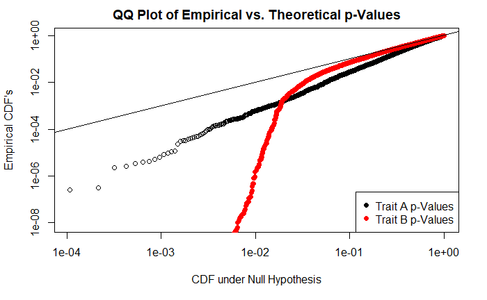

```r
abline(0,1)
legend("bottomright",
       legend = c("Trait A p-Values", "Trait B p-Values"),
       col = c("black", "red"),
       pch = c(19, 19))
```

Notice that the empirical CDF’s lie below the 45-degree line. This means that a given quantile (percentage of the data) has a lower value in the datasets than would have occurred under the null hypothesis. In plainer terms, there are more small p-values in reality than in theory. We might be most interested in the number of SNPs with particularly small p-values, e.g. p < 0.01. At y=0.01, the black line is to the right of the red line, indicating that more of trait A’s p-values are very small. We should therefore expect that more SNPs affect trait A than trait B.